# Risk Factor Analysis

## Outcome Variable

**Outcome Variable:** swasted

## Predictor Variables

**Intervention Variable:** earlybf

**Adjustment Set:**

unadjusted

## Stratifying Variables

The analysis was stratified on these variable(s):

- agecat
- studyid
- country

## Data Summary

| agecat | studyid | country | earlybf | swasted | n_cell | n |
| --- | --- | --- | --- | --- | --- | --- |
| Birth | EE | PAKISTAN | 1 | 0 | 34 | 170 |
| Birth | EE | PAKISTAN | 1 | 1 | 2 | 170 |
| Birth | EE | PAKISTAN | 0 | 0 | 130 | 170 |
| Birth | EE | PAKISTAN | 0 | 1 | 4 | 170 |
| Birth | GMS-Nepal | NEPAL | 1 | 0 | 162 | 586 |
| Birth | GMS-Nepal | NEPAL | 1 | 1 | 9 | 586 |
| Birth | GMS-Nepal | NEPAL | 0 | 0 | 398 | 586 |
| Birth | GMS-Nepal | NEPAL | 0 | 1 | 17 | 586 |
| Birth | JiVitA-3 | BANGLADESH | 1 | 0 | 103 | 17943 |
| Birth | JiVitA-3 | BANGLADESH | 1 | 1 | 2 | 17943 |
| Birth | JiVitA-3 | BANGLADESH | 0 | 0 | 17492 | 17943 |
| Birth | JiVitA-3 | BANGLADESH | 0 | 1 | 346 | 17943 |
| Birth | JiVitA-4 | BANGLADESH | 1 | 0 | 1611 | 2396 |
| Birth | JiVitA-4 | BANGLADESH | 1 | 1 | 13 | 2396 |
| Birth | JiVitA-4 | BANGLADESH | 0 | 0 | 754 | 2396 |
| Birth | JiVitA-4 | BANGLADESH | 0 | 1 | 18 | 2396 |
| Birth | MAL-ED | BANGLADESH | 1 | 0 | 135 | 214 |
| Birth | MAL-ED | BANGLADESH | 1 | 1 | 5 | 214 |
| Birth | MAL-ED | BANGLADESH | 0 | 0 | 71 | 214 |
| Birth | MAL-ED | BANGLADESH | 0 | 1 | 3 | 214 |
| Birth | MAL-ED | BRAZIL | 1 | 0 | 26 | 62 |
| Birth | MAL-ED | BRAZIL | 1 | 1 | 0 | 62 |
| Birth | MAL-ED | BRAZIL | 0 | 0 | 36 | 62 |
| Birth | MAL-ED | BRAZIL | 0 | 1 | 0 | 62 |
| Birth | MAL-ED | INDIA | 1 | 0 | 31 | 44 |
| Birth | MAL-ED | INDIA | 1 | 1 | 0 | 44 |
| Birth | MAL-ED | INDIA | 0 | 0 | 13 | 44 |
| Birth | MAL-ED | INDIA | 0 | 1 | 0 | 44 |
| Birth | MAL-ED | NEPAL | 1 | 0 | 14 | 26 |
| Birth | MAL-ED | NEPAL | 1 | 1 | 0 | 26 |

[output cut: 134 more lines]

The following strata were considered:

- agecat: 24 months, studyid: EE, country: PAKISTAN
- agecat: 24 months, studyid: GMS-Nepal, country: NEPAL
- agecat: 24 months, studyid: JiVitA-3, country: BANGLADESH
- agecat: 24 months, studyid: JiVitA-4, country: BANGLADESH
- agecat: 24 months, studyid: MAL-ED, country: BANGLADESH
- agecat: 24 months, studyid: MAL-ED, country: BRAZIL
- agecat: 24 months, studyid: MAL-ED, country: INDIA
- agecat: 24 months, studyid: MAL-ED, country: NEPAL
- agecat: 24 months, studyid: MAL-ED, country: PERU
- agecat: 24 months, studyid: MAL-ED, country: SOUTH AFRICA
- agecat: 24 months, studyid: MAL-ED, country: TANZANIA, UNITED REPUBLIC OF
- agecat: 24 months, studyid: NIH-Crypto, country: BANGLADESH
- agecat: 24 months, studyid: ZVITAMBO, country: ZIMBABWE
- agecat: 6 months, studyid: EE, country: PAKISTAN
- agecat: 6 months, studyid: GMS-Nepal, country: NEPAL
- agecat: 6 months, studyid: JiVitA-3, country: BANGLADESH
- agecat: 6 months, studyid: JiVitA-4, country: BANGLADESH
- agecat: 6 months, studyid: MAL-ED, country: BANGLADESH
- agecat: 6 months, studyid: MAL-ED, country: BRAZIL
- agecat: 6 months, studyid: MAL-ED, country: INDIA
- agecat: 6 months, studyid: MAL-ED, country: NEPAL
- agecat: 6 months, studyid: MAL-ED, country: PERU
- agecat: 6 months, studyid: MAL-ED, country: SOUTH AFRICA
- agecat: 6 months, studyid: MAL-ED, country: TANZANIA, UNITED REPUBLIC OF
- agecat: 6 months, studyid: NIH-Crypto, country: BANGLADESH
- agecat: 6 months, studyid: SAS-CompFeed, country: INDIA
- agecat: 6 months, studyid: ZVITAMBO, country: ZIMBABWE
- agecat: Birth, studyid: EE, country: PAKISTAN
- agecat: Birth, studyid: GMS-Nepal, country: NEPAL
- agecat: Birth, studyid: JiVitA-3, country: BANGLADESH
- agecat: Birth, studyid: JiVitA-4, country: BANGLADESH
- agecat: Birth, studyid: MAL-ED, country: BANGLADESH
- agecat: Birth, studyid: MAL-ED, country: BRAZIL
- agecat: Birth, studyid: MAL-ED, country: INDIA
- agecat: Birth, studyid: MAL-ED, country: NEPAL
- agecat: Birth, studyid: MAL-ED, country: PERU
- agecat: Birth, studyid: MAL-ED, country: SOUTH AFRICA
- agecat: Birth, studyid: MAL-ED, country: TANZANIA, UNITED REPUBLIC OF
- agecat: Birth, studyid: NIH-Crypto, country: BANGLADESH
- agecat: Birth, studyid: SAS-CompFeed, country: INDIA
- agecat: Birth, studyid: ZVITAMBO, country: ZIMBABWE

### Dropped Strata

Some strata were dropped due to rare outcomes:

- agecat: Birth, studyid: EE, country: PAKISTAN
- agecat: Birth, studyid: JiVitA-3, country: BANGLADESH
- agecat: Birth, studyid: MAL-ED, country: BANGLADESH
- agecat: Birth, studyid: MAL-ED, country: BRAZIL
- agecat: Birth, studyid: MAL-ED, country: INDIA
- agecat: Birth, studyid: MAL-ED, country: NEPAL
- agecat: Birth, studyid: MAL-ED, country: PERU
- agecat: Birth, studyid: MAL-ED, country: SOUTH AFRICA
- agecat: Birth, studyid: MAL-ED, country: TANZANIA, UNITED REPUBLIC OF
- agecat: Birth, studyid: SAS-CompFeed, country: INDIA
- agecat: 6 months, studyid: EE, country: PAKISTAN
- agecat: 6 months, studyid: GMS-Nepal, country: NEPAL
- agecat: 6 months, studyid: JiVitA-3, country: BANGLADESH
- agecat: 6 months, studyid: MAL-ED, country: BANGLADESH
- agecat: 6 months, studyid: MAL-ED, country: BRAZIL
- agecat: 6 months, studyid: MAL-ED, country: INDIA
- agecat: 6 months, studyid: MAL-ED, country: NEPAL
- agecat: 6 months, studyid: MAL-ED, country: PERU
- agecat: 6 months, studyid: MAL-ED, country: SOUTH AFRICA
- agecat: 6 months, studyid: MAL-ED, country: TANZANIA, UNITED REPUBLIC OF
- agecat: 6 months, studyid: NIH-Crypto, country: BANGLADESH
- agecat: 24 months, studyid: EE, country: PAKISTAN
- agecat: 24 months, studyid: GMS-Nepal, country: NEPAL
- agecat: 24 months, studyid: JiVitA-3, country: BANGLADESH
- agecat: 24 months, studyid: MAL-ED, country: BANGLADESH
- agecat: 24 months, studyid: MAL-ED, country: BRAZIL
- agecat: 24 months, studyid: MAL-ED, country: INDIA
- agecat: 24 months, studyid: MAL-ED, country: NEPAL
- agecat: 24 months, studyid: MAL-ED, country: PERU
- agecat: 24 months, studyid: MAL-ED, country: SOUTH AFRICA
- agecat: 24 months, studyid: MAL-ED, country: TANZANIA, UNITED REPUBLIC OF
- agecat: 24 months, studyid: NIH-Crypto, country: BANGLADESH

## Methods Detail

We’re interested in the causal parameters $E[Y_a]$ for all values of $a \in \mathcal{A}$. These parameters represent the mean outcome if, possibly contrary to fact, we intervened to set all units to have $A=a$. Under the randomization and positivity assumptions, these are identified by the statistical parameters $\psi_a=E_W[E_{Y|A,W}(Y|A=a,W)]$. In addition, we’re interested in the mean of $Y$, $E[Y]$ under no intervention (the observed mean). We will estimate these parameters by using SuperLearner to fit the relevant likelihood factors – $E_{Y|A,W}(Y|A=a,W)$ and $p(A=a|W)$, and then updating our likelihood fit using a joint TMLE.

For unadjusted analyses ($W=\{\}$), initial likelihoods were estimated using Lrnr_glm to estimate the simple $E(Y|A)$ and Lrnr_mean to estimate $p(A)$. For adjusted analyses, a small library containing Lrnr_glmnet, Lrnr_xgboost, and Lrnr_mean was used.

Having estimated these parameters, we will then use the delta method to estimate relative risks and attributable risks relative to a prespecified baseline level of $A$.

# Results Detail

## Results Plots

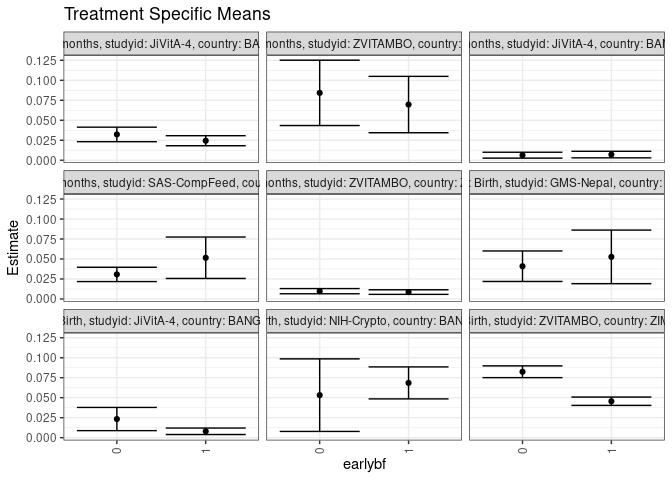

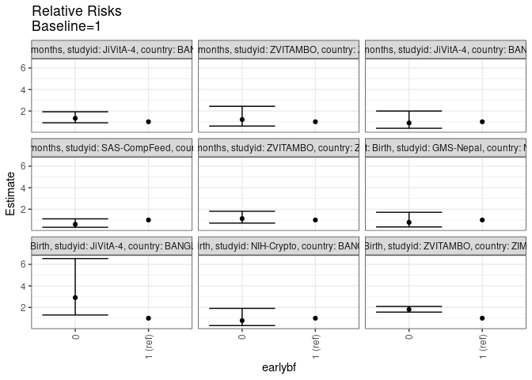

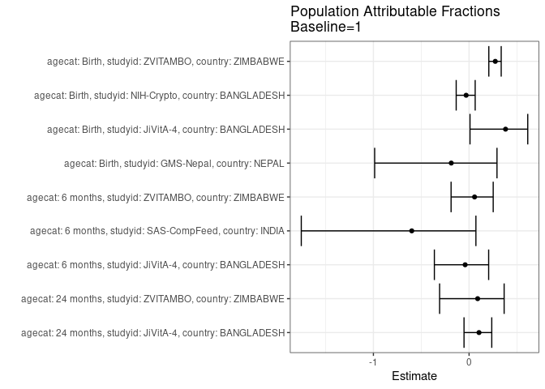

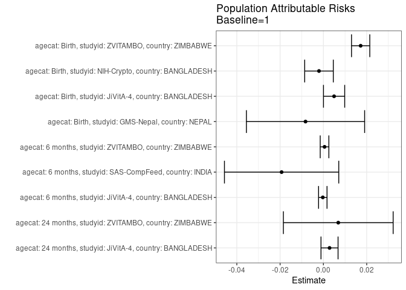

## Results Table

### Parameter: TSM

| agecat | studyid | country | intervention_level | baseline_level | estimate | ci_lower | ci_upper |
| --- | --- | --- | --- | --- | --- | --- | --- |
| Birth | GMS-Nepal | NEPAL | 1 | NA | 0.0526316 | 0.0191348 | 0.0861284 |
| Birth | GMS-Nepal | NEPAL | 0 | NA | 0.0409639 | 0.0218779 | 0.0600498 |
| Birth | JiVitA-4 | BANGLADESH | 1 | NA | 0.0080049 | 0.0039565 | 0.0120533 |
| Birth | JiVitA-4 | BANGLADESH | 0 | NA | 0.0233161 | 0.0088163 | 0.0378159 |
| Birth | NIH-Crypto | BANGLADESH | 1 | NA | 0.0685155 | 0.0485027 | 0.0885283 |
| Birth | NIH-Crypto | BANGLADESH | 0 | NA | 0.0531915 | 0.0077928 | 0.0985902 |
| Birth | ZVITAMBO | ZIMBABWE | 1 | NA | 0.0455878 | 0.0403710 | 0.0508046 |
| Birth | ZVITAMBO | ZIMBABWE | 0 | NA | 0.0824646 | 0.0751086 | 0.0898207 |
| 6 months | JiVitA-4 | BANGLADESH | 1 | NA | 0.0071082 | 0.0030192 | 0.0111973 |
| 6 months | JiVitA-4 | BANGLADESH | 0 | NA | 0.0063291 | 0.0026465 | 0.0100118 |
| 6 months | SAS-CompFeed | INDIA | 1 | NA | 0.0515464 | 0.0256358 | 0.0774570 |
| 6 months | SAS-CompFeed | INDIA | 0 | NA | 0.0307195 | 0.0217846 | 0.0396544 |
| 6 months | ZVITAMBO | ZIMBABWE | 1 | NA | 0.0086101 | 0.0057697 | 0.0114504 |
| 6 months | ZVITAMBO | ZIMBABWE | 0 | NA | 0.0097477 | 0.0064870 | 0.0130084 |
| 24 months | JiVitA-4 | BANGLADESH | 1 | NA | 0.0244144 | 0.0181484 | 0.0306804 |
| 24 months | JiVitA-4 | BANGLADESH | 0 | NA | 0.0322770 | 0.0232095 | 0.0413445 |
| 24 months | ZVITAMBO | ZIMBABWE | 1 | NA | 0.0696517 | 0.0344136 | 0.1048898 |
| 24 months | ZVITAMBO | ZIMBABWE | 0 | NA | 0.0842697 | 0.0434066 | 0.1251328 |

### Parameter: E(Y)

| agecat | studyid | country | intervention_level | baseline_level | estimate | ci_lower | ci_upper |
| --- | --- | --- | --- | --- | --- | --- | --- |
| Birth | GMS-Nepal | NEPAL | NA | NA | 0.0443686 | 0.0276826 | 0.0610546 |
| Birth | JiVitA-4 | BANGLADESH | NA | NA | 0.0129382 | 0.0075150 | 0.0183614 |
| Birth | NIH-Crypto | BANGLADESH | NA | NA | 0.0664781 | 0.0481022 | 0.0848539 |
| Birth | ZVITAMBO | ZIMBABWE | NA | NA | 0.0627931 | 0.0583619 | 0.0672244 |
| 6 months | JiVitA-4 | BANGLADESH | NA | NA | 0.0068281 | 0.0038634 | 0.0097927 |
| 6 months | SAS-CompFeed | INDIA | NA | NA | 0.0322339 | 0.0235219 | 0.0409459 |
| 6 months | ZVITAMBO | ZIMBABWE | NA | NA | 0.0091354 | 0.0069896 | 0.0112812 |
| 24 months | JiVitA-4 | BANGLADESH | NA | NA | 0.0272439 | 0.0220352 | 0.0324527 |
| 24 months | ZVITAMBO | ZIMBABWE | NA | NA | 0.0765172 | 0.0497195 | 0.1033148 |

### Parameter: RR

| agecat | studyid | country | intervention_level | baseline_level | estimate | ci_lower | ci_upper |
| --- | --- | --- | --- | --- | --- | --- | --- |
| Birth | GMS-Nepal | NEPAL | 1 | 1 | 1.0000000 | 1.0000000 | 1.000000 |
| Birth | GMS-Nepal | NEPAL | 0 | 1 | 0.7783133 | 0.3536728 | 1.712802 |
| Birth | JiVitA-4 | BANGLADESH | 1 | 1 | 1.0000000 | 1.0000000 | 1.000000 |
| Birth | JiVitA-4 | BANGLADESH | 0 | 1 | 2.9127142 | 1.2976313 | 6.537993 |
| Birth | NIH-Crypto | BANGLADESH | 1 | 1 | 1.0000000 | 1.0000000 | 1.000000 |
| Birth | NIH-Crypto | BANGLADESH | 0 | 1 | 0.7763425 | 0.3149772 | 1.913496 |
| Birth | ZVITAMBO | ZIMBABWE | 1 | 1 | 1.0000000 | 1.0000000 | 1.000000 |
| Birth | ZVITAMBO | ZIMBABWE | 0 | 1 | 1.8089206 | 1.5646096 | 2.091380 |
| 6 months | JiVitA-4 | BANGLADESH | 1 | 1 | 1.0000000 | 1.0000000 | 1.000000 |
| 6 months | JiVitA-4 | BANGLADESH | 0 | 1 | 0.8903913 | 0.3968951 | 1.997497 |
| 6 months | SAS-CompFeed | INDIA | 1 | 1 | 1.0000000 | 1.0000000 | 1.000000 |
| 6 months | SAS-CompFeed | INDIA | 0 | 1 | 0.5959580 | 0.3210516 | 1.106258 |
| 6 months | ZVITAMBO | ZIMBABWE | 1 | 1 | 1.0000000 | 1.0000000 | 1.000000 |
| 6 months | ZVITAMBO | ZIMBABWE | 0 | 1 | 1.1321265 | 0.7077149 | 1.811055 |
| 24 months | JiVitA-4 | BANGLADESH | 1 | 1 | 1.0000000 | 1.0000000 | 1.000000 |
| 24 months | JiVitA-4 | BANGLADESH | 0 | 1 | 1.3220483 | 0.9062703 | 1.928577 |
| 24 months | ZVITAMBO | ZIMBABWE | 1 | 1 | 1.0000000 | 1.0000000 | 1.000000 |
| 24 months | ZVITAMBO | ZIMBABWE | 0 | 1 | 1.2098716 | 0.6003371 | 2.438279 |

### Parameter: PAR

| agecat | studyid | country | intervention_level | baseline_level | estimate | ci_lower | ci_upper |
| --- | --- | --- | --- | --- | --- | --- | --- |
| Birth | GMS-Nepal | NEPAL | 1 | NA | -0.0082630 | -0.0355690 | 0.0190431 |
| Birth | JiVitA-4 | BANGLADESH | 1 | NA | 0.0049333 | 0.0000329 | 0.0098337 |
| Birth | NIH-Crypto | BANGLADESH | 1 | NA | -0.0020374 | -0.0086451 | 0.0045702 |
| Birth | ZVITAMBO | ZIMBABWE | 1 | NA | 0.0172054 | 0.0129845 | 0.0214263 |
| 6 months | JiVitA-4 | BANGLADESH | 1 | NA | -0.0002802 | -0.0022342 | 0.0016739 |
| 6 months | SAS-CompFeed | INDIA | 1 | NA | -0.0193125 | -0.0457136 | 0.0070885 |
| 6 months | ZVITAMBO | ZIMBABWE | 1 | NA | 0.0005254 | -0.0014717 | 0.0025224 |
| 24 months | JiVitA-4 | BANGLADESH | 1 | NA | 0.0028295 | -0.0011105 | 0.0067696 |
| 24 months | ZVITAMBO | ZIMBABWE | 1 | NA | 0.0068654 | -0.0184872 | 0.0322181 |

### Parameter: PAF

| agecat | studyid | country | intervention_level | baseline_level | estimate | ci_lower | ci_upper |
| --- | --- | --- | --- | --- | --- | --- | --- |
| Birth | GMS-Nepal | NEPAL | 1 | NA | -0.1862348 | -0.9869502 | 0.2918026 |
| Birth | JiVitA-4 | BANGLADESH | 1 | NA | 0.3812967 | 0.0098584 | 0.6133949 |
| Birth | NIH-Crypto | BANGLADESH | 1 | NA | -0.0306480 | -0.1346550 | 0.0638253 |
| Birth | ZVITAMBO | ZIMBABWE | 1 | NA | 0.2740008 | 0.2063738 | 0.3358651 |
| 6 months | JiVitA-4 | BANGLADESH | 1 | NA | -0.0410339 | -0.3627638 | 0.2047399 |
| 6 months | SAS-CompFeed | INDIA | 1 | NA | -0.5991369 | -1.7539793 | 0.0714386 |
| 6 months | ZVITAMBO | ZIMBABWE | 1 | NA | 0.0575075 | -0.1880083 | 0.2522847 |
| 24 months | JiVitA-4 | BANGLADESH | 1 | NA | 0.1038596 | -0.0527581 | 0.2371774 |
| 24 months | ZVITAMBO | ZIMBABWE | 1 | NA | 0.0897238 | -0.3081209 | 0.3665702 |